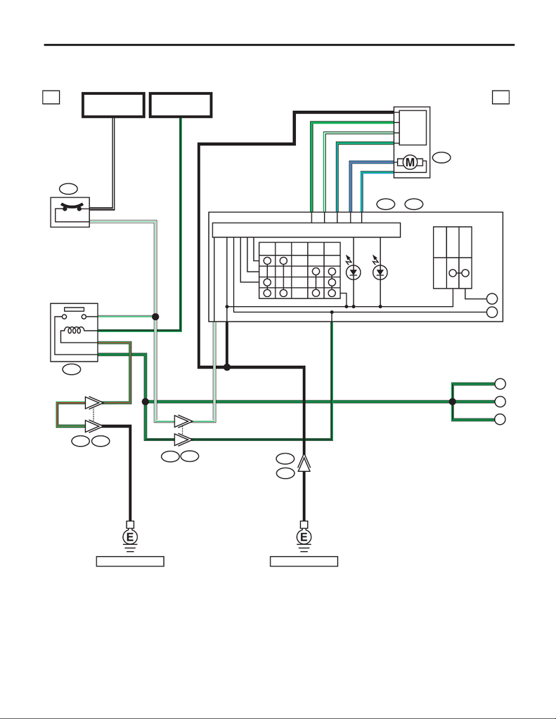

WI-324

Power Window System

WIRING SYSTEM

37.Power Window System

A: WIRING DIAGRAM

WI-44516

a a

D11

B101

i101

D84

B225

C

D3

D7

A:

D102

B:

OFFUP

AUTO

UP

DOWN

AUTO

DOWN

UNLOCK LOCK

A

B

B41

E

D

3

3

7

B/W

G/B

A10

A4

A5

B1

B3

B2W/G

A1B

A14

G/B

BB

B

B

G/BG/B

W/G

B

G

G/W

G/L

2

3

5

6

4

1L/G

L/R

W/G

B/W2

W/G1

W/G7

G/B

G/B

G/B

6

9

G/B

G/B

G/R

8

B181B182

1

2

G/R

B

G/R

G/R

MB-30

SBF-4

(B)

POWER WINDOW

CIRCUIT BREAKER

SWITCH ILLUMI. LIGHT

SWITCH ILLUMI. LIGHT

POWER WINDOW CONTROLLER

POWER WINDOW

LOCK SWITCH

FRONT

POWER WINDOW

MOTOR LH

POWER WINDOW

MAIN SWITCH

POWER WINDOW

RELAY

FB-42

F/B FUSE NO. 26

(IG)

REF. TO GND [j]REF. TO GND [b]

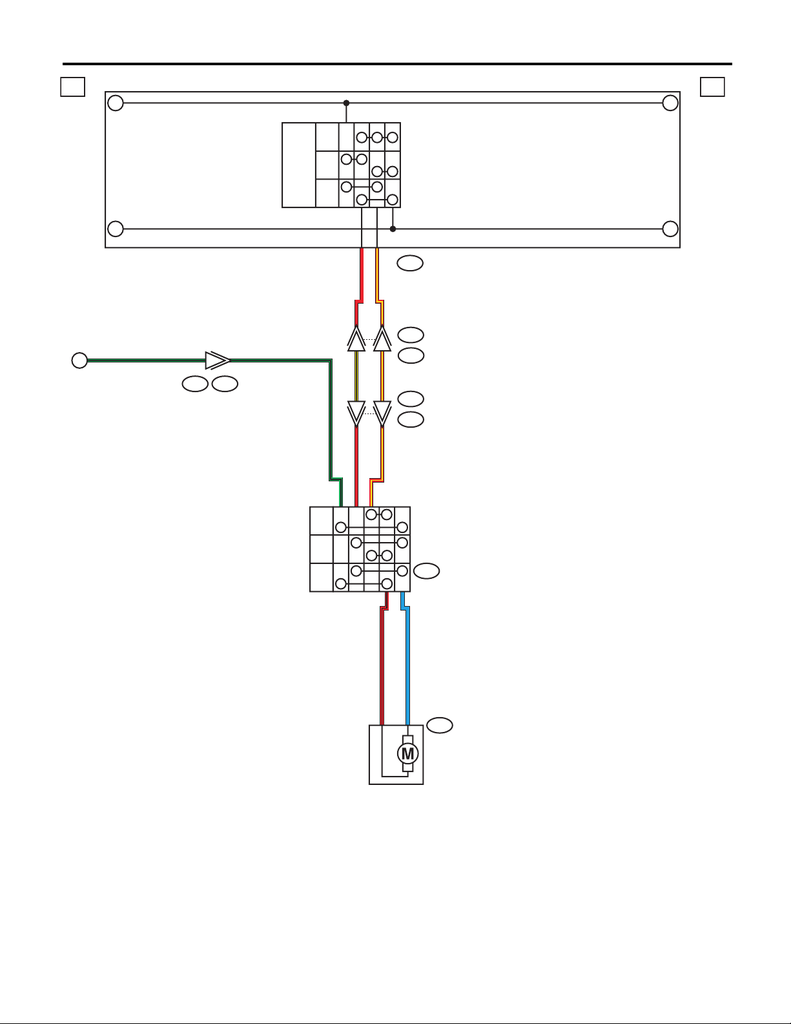

WI-325

Power Window System

WIRING SYSTEM

WI-44517

b b

D84

i101

D83

i76

4

5

6

D17

D13

G/BG/B G/B

OFF

DOWN

UP

UP

DOWN

OFF

B

A

C

F

G

D7A:

B30

D1

6

5

7

A2R/Y

A8R

R/Y

R

G/B

R/Y

Y/B

3

6

L

R/B

6

7

8

5

POWER WINDOW MAIN SWITCH

FRONT

RH

FRONT

POWER WINDOW

MOTOR RH

FRONT

POWER WINDOW

SUB-SWITCH

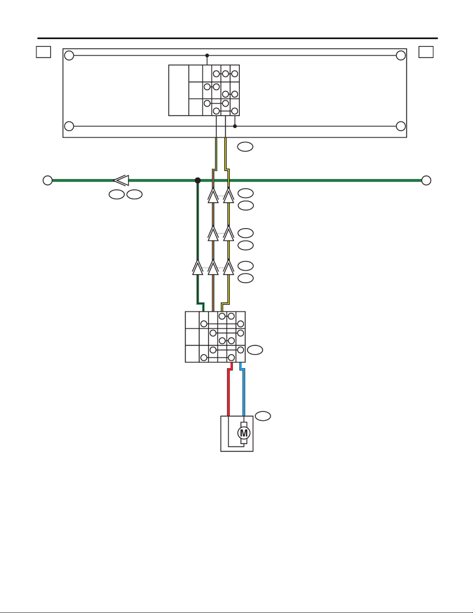

WI-326

Power Window System

WIRING SYSTEM

WI-44518

c c

4

D84

i101

R167

i102

D22

R10

B/Y B/Y

4

1

L

R

7

8

5

B/Y

G/R G/R G/R

G/B G/B6

A15G/R

A16B/Y

D25

D24

G/BG/B G/B

OFF

DOWN

UP

UP

DOWN

OFF

F

G

D

H

I

D7A:

B99

R3

9

10

7

8

3

1

2

3

J

G/BG/B

POWER WINDOW MAIN SWITCH

REAR

LH

REAR

POWER WINDOW

MOTOR LH

REAR

POWER WINDOW

SWITCH LH

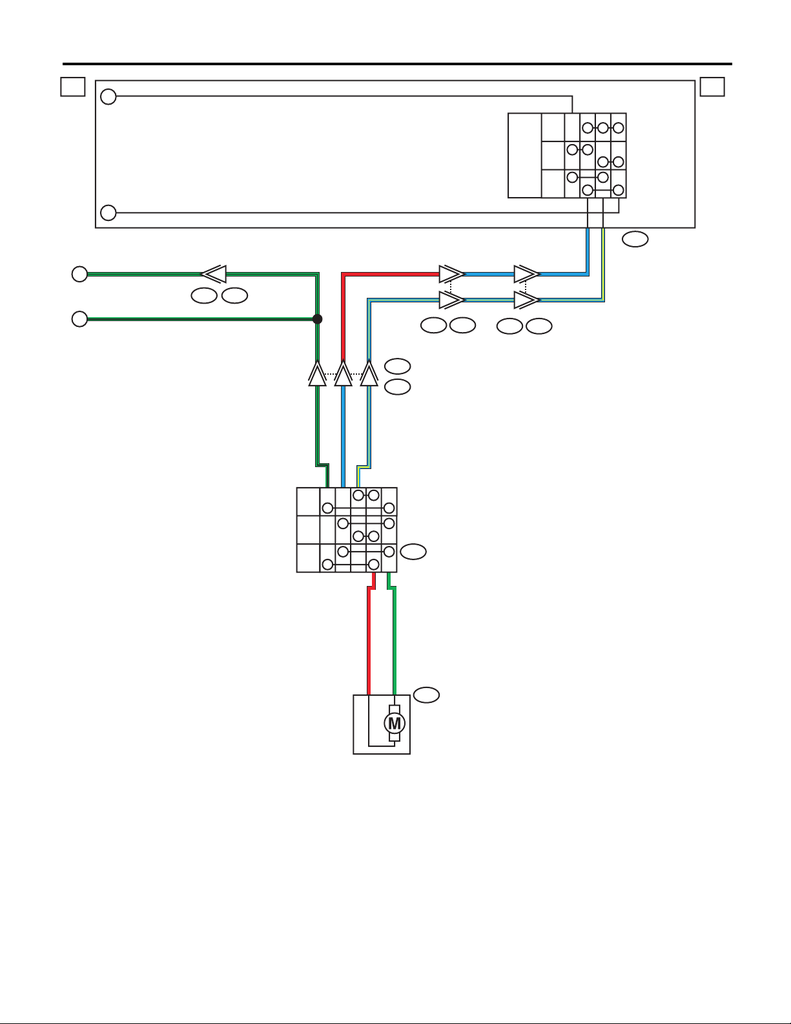

WI-327

Power Window System

WIRING SYSTEM

WI-44519

d d

D28

R13

R98 i53

E

D31

D30

B97

R1

i101 D84

D7A:

OFF

DOWN

UP

UP

DOWN

OFF

H

I

7

8

9

10

2

L/Y

RG/BG/BG/B

J

G/B

L/Y

L

L/Y

L

G/B

L/Y

R

G

R

3

6

L/Y

L

G/B

A6

A7

4

6

7

8

5

1

2

3

REAR

RH

POWER WINDOW

MAIN SWITCH

REAR

POWER WINDOW

MOTOR RH

REAR

POWER WINDOW

SWITCH RH

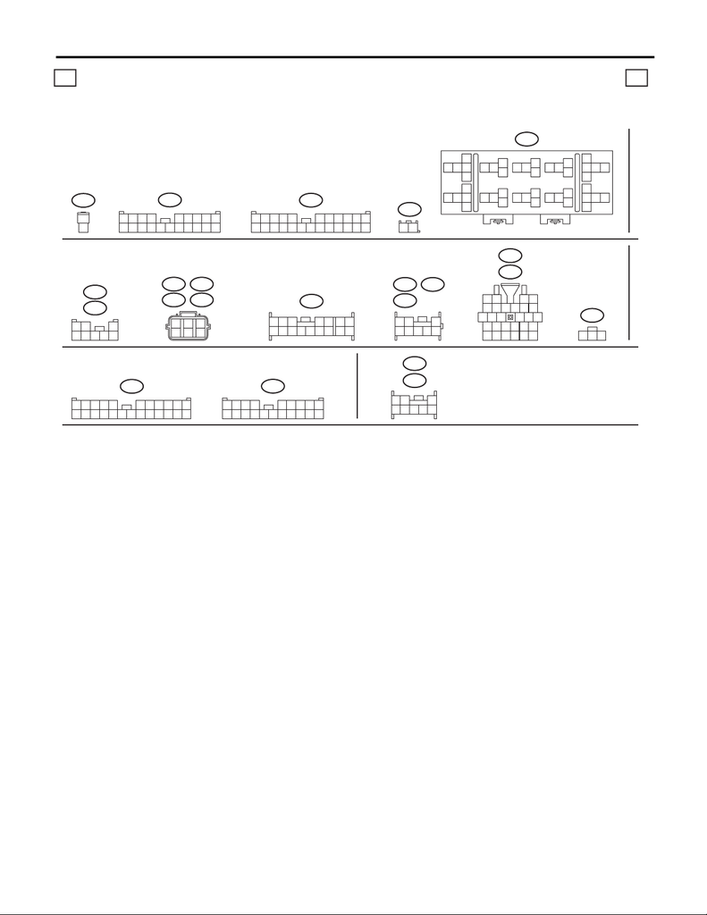

WI-328

Power Window System

WIRING SYSTEM

B225

10 11

12

13

14 15

16

18

19 21 22

20

17

24

5

3

17

9

8

6

32 33

34

35

28262423

25

27

29

30

31

36 37

38

40

41 43 44

42

39

WI-44520

e e

B41

2

1

3412 89

10 11

12 13 14 15 16 17 18 19 20 21 22 23 24

567

B99

89

19 20

1234 567

10 11 12 13 14 15 16 17 18

B97

B181

12

D7

123

89

10

4

11 12 13 14 15 16

56

7

A:

D84

D83

19

18

20 21 22

1514131211

1

3

24

5

7

6

98

10

17

25

24

26 27 2823

16

3412 89

10 11

12 13 14 15 16 17 18 19 20 21 22 23 24

567

i53

89

19 20

1234 567

10 11 12 13 14 15 16 17 18

i102

R13

R10

65

21

4

3

87

D1

D11

321

87654

D30

D24

3

4

2

1

56

(GR)

(GR)

D13

D3

(GR)

(GR)

RELAY HOLDER

LIST OF CONNECTORS

D31

D25

D17

785

6

3

4

21

D102

123

B: